# SPS_Data607_Week9_DC

**Assignment: Using a New York Times API in R**

The New York Times provides multiple public APIs via its developer portal (NYT Developer Network). To use any NYT API, you must first **create an account and obtain an API key**.

Your task:

1. **Choose one** New York Times API endpoint (e.g., Article Search, Most Popular, Books, etc.). You should use your data analysis to ask and attempt to answer an interesting question of your choosing. Examples: “What are the top five best selling hard cover books?”, “Which newspaper sections have produced the most popular articles, and how has this changed compared to X years ago?”, etc.
2. In **R**, write code to:

```
-    Authenticate using your API key.
Never hard code an API key.
There are a number of good ways to do this.
For example: Store it in an environment variable
(e.g., `Sys.getenv("NYT_API_KEY"`)).

-    Make a request to the endpoint

-    Parse the **JSON** response

-    Transform the result into a clean **R data frame** (tibble is fine)
```

**Deliverable**

- A single Quarto (.qmd) document that includes:

```
-    The API you selected (endpoint + brief description)

-    The request you made (parameters used)

-    Code that returns a tidy data frame

-    A short note describing any data-cleaning decisions (e.g., nested fields, missing values)
```

## Approach

- Talk to the The New York Times API
- Handle JSON data (API responses)
- Clean and analyze data
- Make charts

## Setup

httr → sends a request to NYT (like opening a webpage automatically)

jsonlite → converts API response into table format

dplyr → lets you filter/select columns easily

ggplot2 → creates graphs

```r
#install.packages(c("httr", "jsonlite", "dplyr", "ggplot2"))
knitr::opts_chunk$set(cache = TRUE)
library(httr)
library(jsonlite)
library(dplyr)
library(ggplot2)
```

Set API key:

```r
Sys.setenv(NYT_API_KEY = "DGkAWyGbtH9guBDRY0seBsnGrdb8Lkx9s2qYsEgyNXTYLT1T7")
```

## API Function

creating a **reusable function** that:

1. asks the New York Times Article Search API for data
   - `query` = what you search (e.g., “China”)
   - `begin_date` / `end_date` = time range
   - `page` = which batch of results
2. returns articles as a table

```r
nyt_search <- function(query, begin_date, end_date, page = 0) {
  api_key <- Sys.getenv("NYT_API_KEY")

  url <- "https://api.nytimes.com/svc/search/v2/articlesearch.json"

  res <- GET(url, query = list(
    q = query,
    begin_date = begin_date,
    end_date = end_date,
    page = page,
    `api-key` = api_key
  ))

  nyt_content <- content(res, as = "text", encoding = "UTF-8")
  #print(nyt_content)
  json <- fromJSON(nyt_content, flatten = TRUE)

  return(json$response$docs)
}
```

## Data Collection

The API does NOT give all results at once

Each request = 10 articles Need a loop to get more

Create a data container with a loop to collect and store all results from API calls. Implement a delay (timer) between requests to prevent the NYT API from rate-limiting or blocking the API key.

```r
all_articles <- list()

for (p in 0:50) {
  #cat("Fetching page:", p, "\n")
  tmp <- nyt_search("China", 19290101, 19291231, p)

  if (length(tmp) == 0) break
  all_articles[[p + 1]] <- tmp

  Sys.sleep(15) # the rate limit is 5 req per 60s
}
```

[output not shown]

```r
df <- bind_rows(all_articles)
```

## Data Cleaning

Raw API data is untidy

- Keep only useful columns
- Rename them
- Fix date format

```r
df_clean <- df %>%
  select(
    headline = headline.main,
    pub_date,
    snippet,
    section_name,
    web_url
  ) %>%
  mutate(pub_date = as.Date(pub_date))

head(df_clean)
```

```
                                                                          headline
1                                                               DOG MEAT IN CHINA.
2                                                           NEW TROUBLES IN CHINA.
3             CHARM OF OLD CHINA TRADE SHOWN IN BUSINESS LETTERS; CHINESE MERCHANT
4                                                 Extends Letter Service in China.
5 EDUCATING CHINESE WOMEN; Support Is Urged for Lingnan University in South China.
6                         China Says She Will Proclaim Full Freedom by End of 1929
    pub_date
1 1929-12-01
2 1929-10-16
3 1929-12-15
4 1929-09-15
5 1929-11-26
6 1929-09-17
                                                                                                snippet
```

[output cut: 20 more lines]

## Analysis

### Articles Over Time

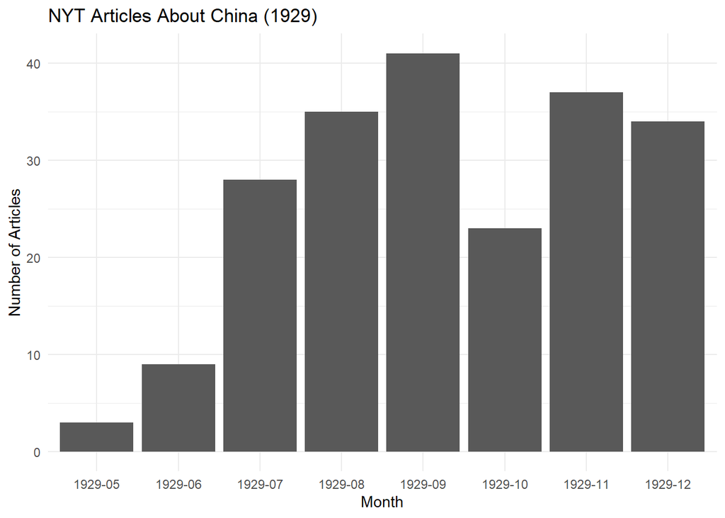

```r
df_clean %>%
  mutate(month = format(pub_date, "%Y-%m")) %>%
  count(month) %>%
  ggplot(aes(x = month, y = n, group = 1)) +
  geom_col() +
  #geom_point() +
  theme_minimal() +
  labs(title = "NYT Articles About China (1929)",
       x = "Month",
       y = "Number of Articles")
```

### Keyword Exploration

```r
war_articles <- df_clean %>%
  filter(grepl("Peking", snippet, ignore.case = TRUE))

head(war_articles)
```

```
                                                                                                                   headline
1                                                                                                        DOG MEAT IN CHINA.
2 CHINA IS DEVELOPING MOTOR AND AIR TRAVEL; Commercial Attache Tells Hoover American Trade Is Gaining There Satisfactorily.
3                                     Kidnapped Furrier Sends Plea for Ransom; Stimson Cables to China to Aid Aaron Brenner
4                                         SEIZE CHINESE TEMPLE.; Workers Turn Monks Out and Smash Idols in Peking Outbreak.
5     CHINESE ART GIVEN PHILADELPHIA MUSEUM; 300 Paintings and Ducal Hall From Peking Are Pesented by Edward B. Robinettes.
    pub_date
1 1929-12-01
2 1929-10-30
3 1929-11-10
4 1929-11-24
5 1929-10-20
                                                                                                                              snippet
1                                          Chow dog flesh still obtainable in Canton and Peiping (Peking) although sale is prohibited
2                                                           Conf of J Arnold, Commercial Attache at Peiping (Peking) with Pres Hoover
3                                                  Brenner asks that random be paid; Amer Minister at Peking instructed to render aid
4 Union of street car workers at Peking seizes temple Tiehshanssu on Kuomintang party's ruling that "superstition" must be eradicated
5                                         Mr and Mrs E B Robinette present 300 Chinese paintings and hall from ducal palace in Peking
  section_name
1     Archives
2     Archives
3     Archives
4     Archives
5     Archives
                                                                                                              web_url
1                                                  https://www.nytimes.com/1929/12/01/archives/dog-meat-in-china.html
2  https://www.nytimes.com/1929/10/30/archives/china-is-developing-motor-and-air-travel-commercial-attache-tells.html
3 https://www.nytimes.com/1929/11/10/archives/kidnapped-furrier-sends-plea-for-ransom-stimson-cables-to-china-to.html
4     https://www.nytimes.com/1929/11/24/archives/seize-chinese-temple-workers-turn-monks-out-and-smash-idols-in.html
5 https://www.nytimes.com/1929/10/20/archives/chinese-art-given-philadelphia-museum-300-paintings-and-ducal-hall.html
```

### LLMS used:

• OpenAI. (2025). ChatGPT (Version 5.2) [Large language model]. https://chat.openai.com. Accessed Mar 28, 2026.